# eDNA_exploration_2021

```r
full.dat.long <- pivot_longer(data = full.dat, cols = c("Aulorhynchus flavidus":"Rhamphocottus richardsonii"), names_to = "species_scientific", values_to = "binary")
```

calculate distances for the combined eDNA/beach seine data

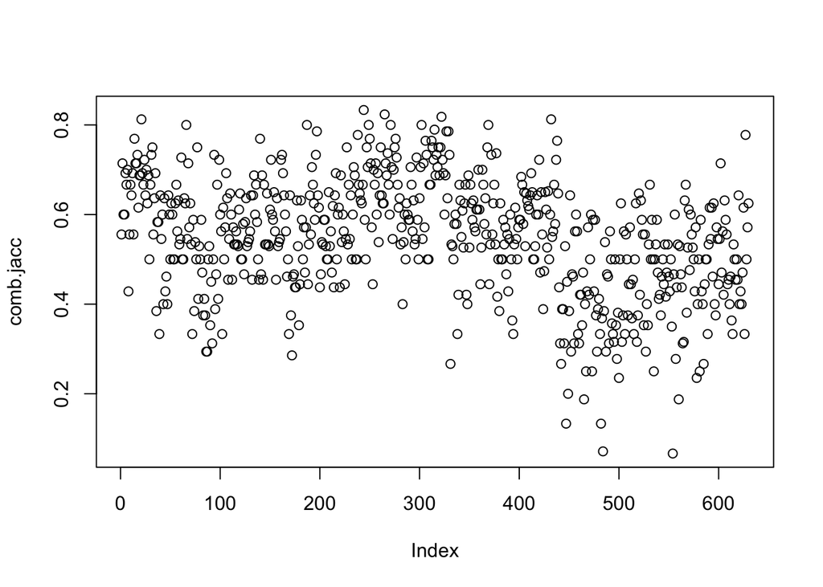

```r
comb.jacc <- vegdist(full.dat, method = "jaccard", binary = T)
plot(comb.jacc)
```

```r
# for just eelgrass sites

full.eel <- full.dat %>%
  rownames_to_column(var = "bay_id_gear") %>%
  separate("bay_id_gear", into = c("bay", "id", "gear"), extra = "merge") %>%
  unite(bay_id, bay:id) %>%
  left_join(seine.info) %>%
  filter(habitat != "kelp") %>%
  unite(bay_id_gear, bay_id:gear) %>%
  column_to_rownames(var = "bay_id_gear") %>%
  dplyr::select(-c(place_name:habitat))
full.kelp <- full.dat %>%
  rownames_to_column(var = "bay_id_gear") %>%
  separate("bay_id_gear", into = c("bay", "id", "gear"), extra = "merge") %>%
  unite(bay_id, bay:id) %>%
  left_join(seine.info) %>%
  filter(habitat == "kelp") %>%
  unite(bay_id_gear, bay_id:gear) %>%
  column_to_rownames(var = "bay_id_gear") %>%
  dplyr::select(-c(place_name:habitat))
```

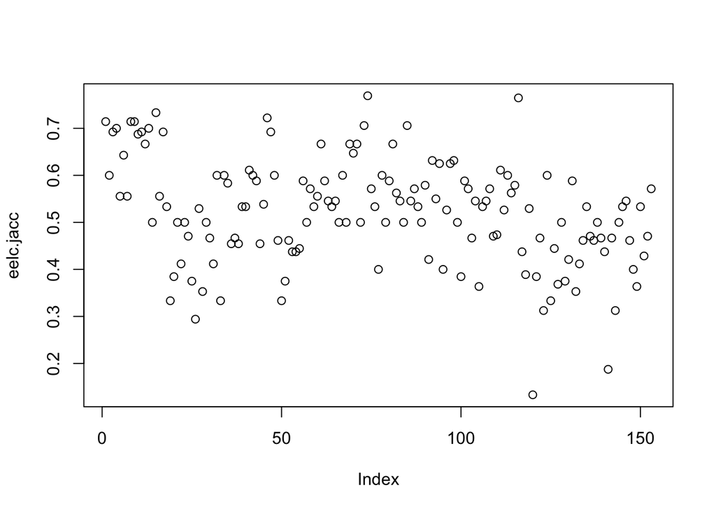

```r
eelc.jacc <- vegdist(full.eel, method = "jaccard", binary = T)
plot(eelc.jacc)
```

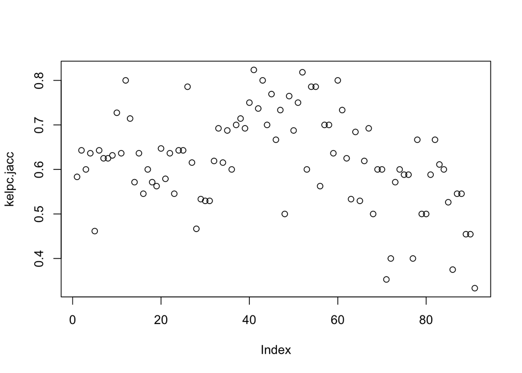

```r
kelpc.jacc <- vegdist(full.kelp, method = "jaccard", binary = T)
plot(kelpc.jacc)
```

## NMDS

```r
comb.nmds <- metaMDS(comb.jacc, k = 2, autotransform = FALSE, distance = "jaccard", maxit = 9999)
```

```
## *** Solution reached
```

```r
comb.nmds$stress # 21% kinda almost past what we should accept
```

```
## [1] 0.215838
```

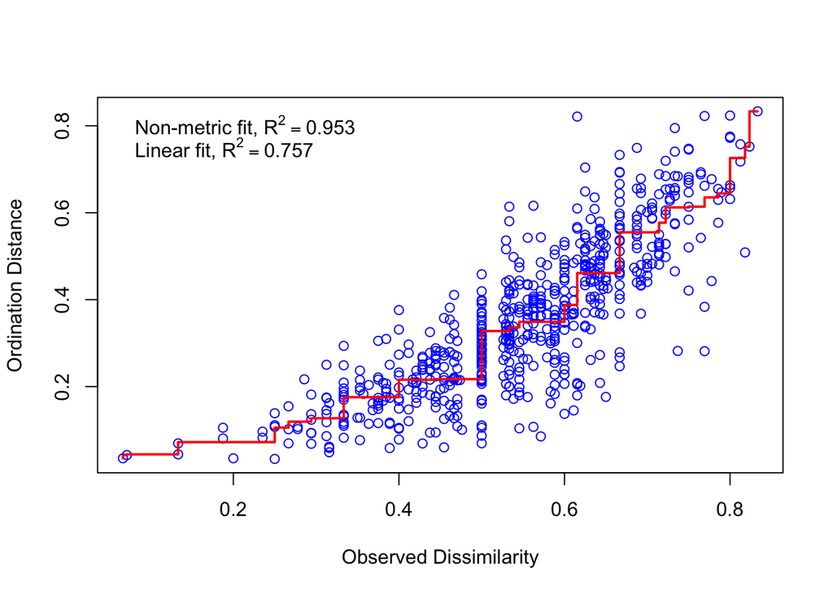

```r
stressplot(comb.nmds)
```

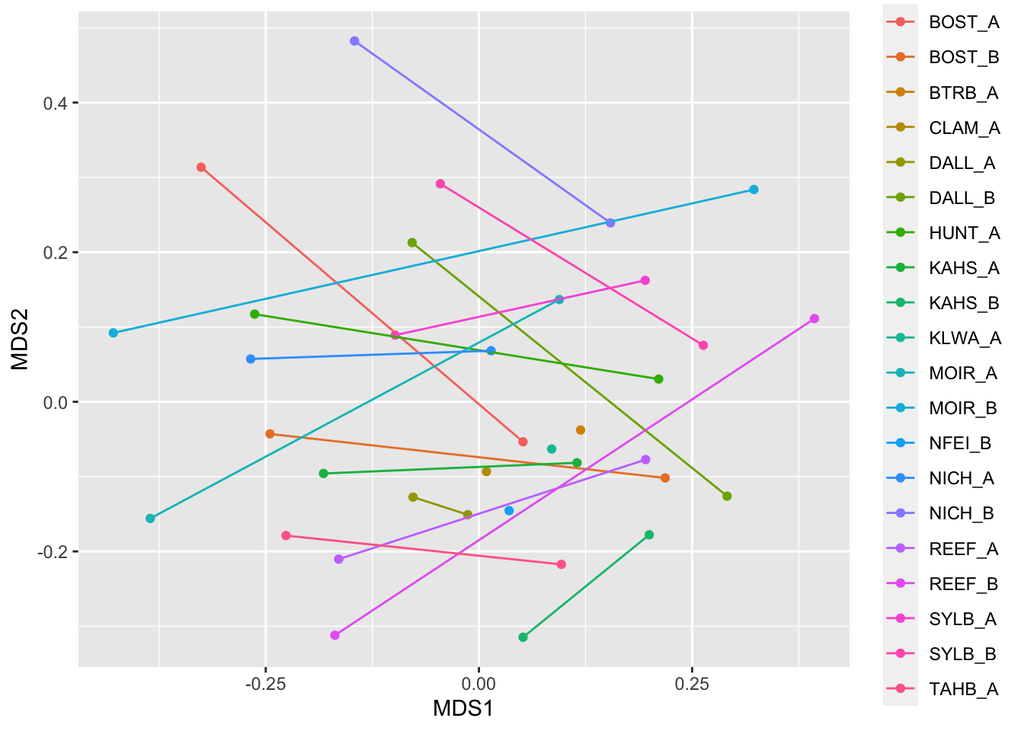

```r
comb.nmds.pts <- as.data.frame(comb.nmds$points)
comb.nmds.pts %>%
  rownames_to_column(var = "bay_id_gear") %>%
  separate(bay_id_gear, into = c("bay", "id", "gear"), extra = "merge") %>%
  unite(bay_id, bay:id) %>%
  ggplot(aes(x = MDS1, y = MDS2, color = bay_id)) +
  geom_point() +
  geom_line()
```

##PCoA

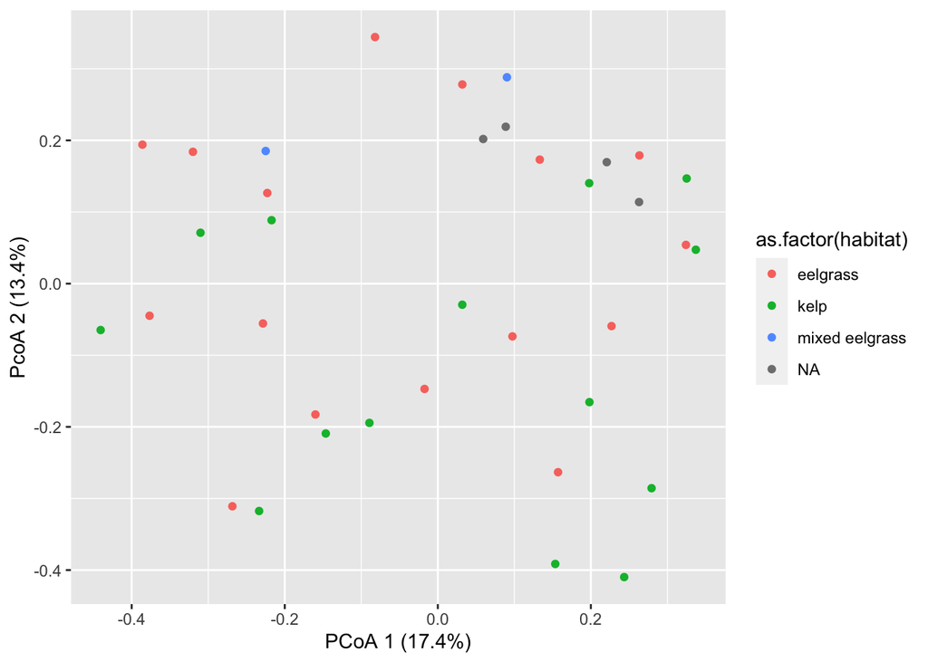

```r
pco.combo <- cmdscale(comb.jacc, k = 2, eig = T, add = T)
colnames(pco.combo$points) <- c("pcoa1", "pcoa2")
# eiganvector - positions on the x and y axis (points)
# eiganvalues - indicate something about the proportion of the variation explained by the different axis. So we can use eiganvalues to get porpotion explained. Some of these eiganvalues are negative. Need to be rescaled (this is done by add = T)

percent_explained3 <- 100* pco.combo$eig/ sum(pco.combo$eig)
pe3 <- format(round(percent_explained3[1:2], digits = 1), nsmall = 1, trim = T)

pco.perc <- c(glue("PCoA 1 ({pe3[1]}%)"),
          glue("PcoA 2 ({pe3[2]}%)"))

pco.combo$points %>%
  as_tibble(rownames = "bay_id_gear") %>%
  separate(bay_id_gear, into = c("bay", "id", "gear", "extra"), extra = "merge") %>%
  dplyr::select(-extra) %>%
  unite(bay_id, bay:id) %>%
  left_join(seine.info) %>%
  ggplot(aes(x = pcoa1, y = pcoa2)) +
  geom_point(aes(color = as.factor(habitat))) +
  labs(x = pco.perc[1], y = pco.perc[2])
```

## Eelgrass pcoa

Lets look at just the eelgrass sites and see how the variability by gear type shows up.

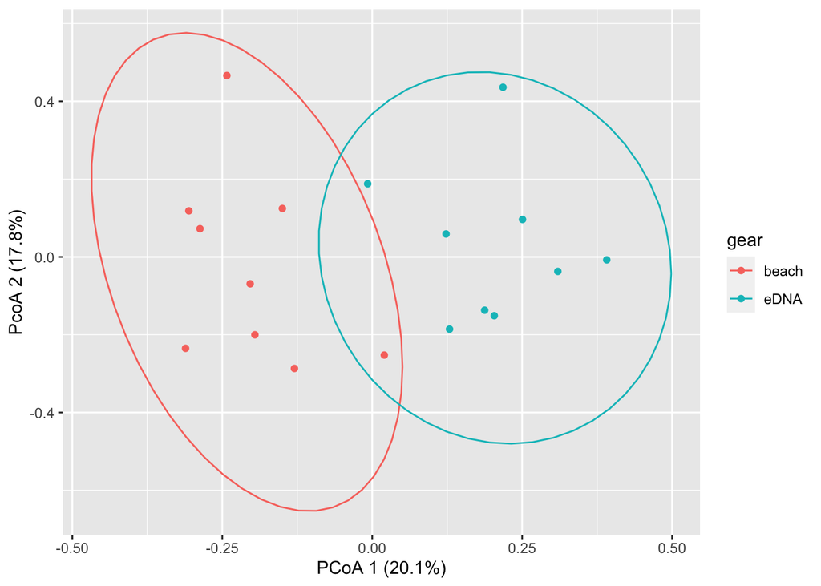

```r
# eelc.jacc - jaccard distance eelgrass only sites (includes mixed eelgrass)
eelc.pco <- cmdscale(eelc.jacc, k =2, eig = T, add = T)

colnames(eelc.pco$points) <- c("pcoa1", "pcoa2")


percent_explained4 <- 100* eelc.pco$eig/ sum(eelc.pco$eig)
pe4 <- format(round(percent_explained4[1:2], digits = 1), nsmall = 1, trim = T)

pco.perc4 <- c(glue("PCoA 1 ({pe4[1]}%)"),
          glue("PcoA 2 ({pe4[2]}%)"))

eelc.pco$points %>%
  as_tibble(rownames = "bay_id_gear") %>%
  separate(bay_id_gear, into = c("bay", "id", "gear", "extra"), extra = "merge") %>%
  dplyr::select(-extra) %>%
  unite(bay_id, bay:id) %>%
  left_join(seine.info) %>%
  ggplot(aes(x = pcoa1, y = pcoa2)) +
  geom_point(aes(color = gear)) +
  labs(x = pco.perc4[1], y = pco.perc4[2], main = "PCoA of eelgrass sites sampled with beach seine or eDNA") +
  stat_ellipse(aes(color = gear))
```

### Eel nmds

Using nmds approaches, we can also test for homogeneity of dispersion and differences between species comp of group.

Randomization test to compare within-group ‘dispersions’ with any distance measure. This tells you if the differences between sites are because of dispersion or variation or if it truly driven by a difference in sites (as can be determined by a PERMANOVA test)

H0 = within-group dispersion have no significant differences.

```r
# extract gear info from distance matrix
gear.eel <- full.eel %>%
  rownames_to_column(var = "bay_id_gear") %>%
  separate(bay_id_gear, into = c("bay", "id", "gear"), extra = "merge") %>%
  dplyr::select(c(bay, id, gear)) %>%
  unite(bay_id, bay:id)

disp.gear <- betadisper(eelc.jacc, gear.eel$gear)
anova(disp.gear)
```

```
## Analysis of Variance Table
##
## Response: Distances
##           Df   Sum Sq   Mean Sq F value Pr(>F)
## Groups     1 0.013085 0.0130849  2.1579 0.1612
## Residuals 16 0.097019 0.0060637
```

H0 accepted, there is no significant variation within gear type groups

PERMANOVA: Then test for significant difference in species composition between gear

PERMANOVA assumption: 1) independence 2) homogeneity of dispersion Meaning samples/objects are exchangeable, if H0 is true. Always test diff in dispersion among groups FIRST (done above w/ betadisper)

```r
# analysis of dispersion accepted the null hypothesis
# This is the test of "location", if there are sig. changes in species composition between gear groups
# H0 no group differences

adonis2(eelc.jacc ~ gear, data = gear.eel)
```

```
## Permutation test for adonis under reduced model
## Terms added sequentially (first to last)
## Permutation: free
## Number of permutations: 999
##
## adonis2(formula = eelc.jacc ~ gear, data = gear.eel)
##          Df SumOfSqs      R2      F Pr(>F)
## gear      1  0.50519 0.20871 4.2201  0.001 ***
## Residual 16  1.91535 0.79129
## Total    17  2.42053 1.00000
## ---
## Signif. codes:  0 '***' 0.001 '**' 0.01 '*' 0.05 '.' 0.1 ' ' 1
```

There is a significant variation in species composition betweeen gear type when comparing beach seine and eDNA. This can be visualized using stat_ellipse in ggplot in the biplot of nmds below.

```r
eel.nmds <- metaMDS(eelc.jacc, k = 2, autotransform = FALSE, distance = "jaccard", maxit = 9999)
```

```
## *** Solution reached
```

```r
eel.nmds$stress # 16% this is good
```

```
## [1] 0.168232
```

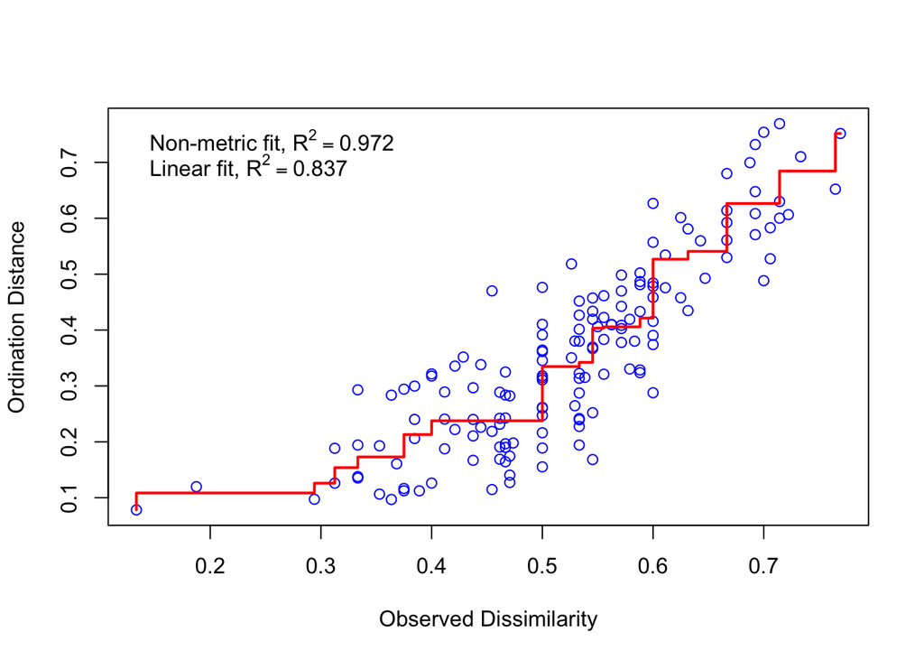

```r
stressplot(eel.nmds)
```

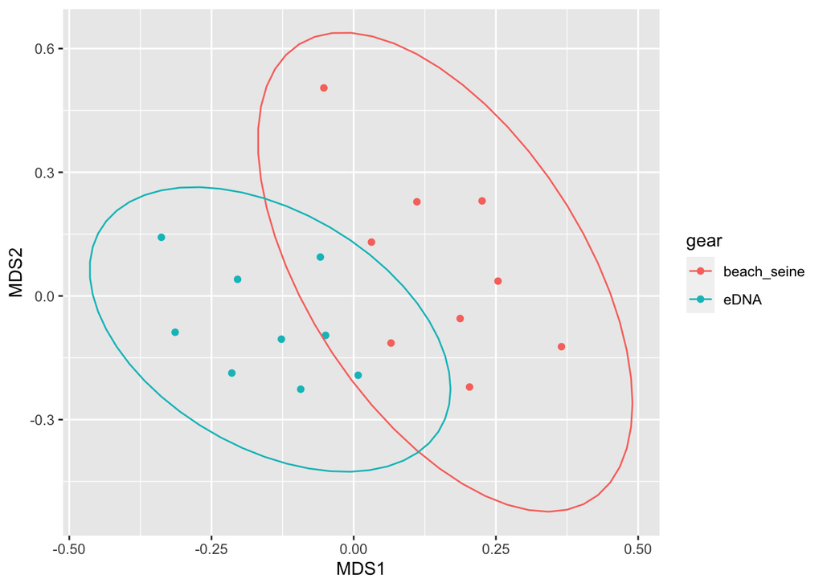

```r
eel.nmds.pts <- as.data.frame(eel.nmds$points)
eel.nmds.pts %>%
  rownames_to_column(var = "bay_id_gear") %>%
  separate(bay_id_gear, into = c("bay", "id", "gear"), extra = "merge") %>%
  unite(bay_id, bay:id) %>%
  ggplot(aes(x = MDS1, y = MDS2, color = gear)) +
  geom_point() +
  stat_ellipse(aes(color = gear))
```

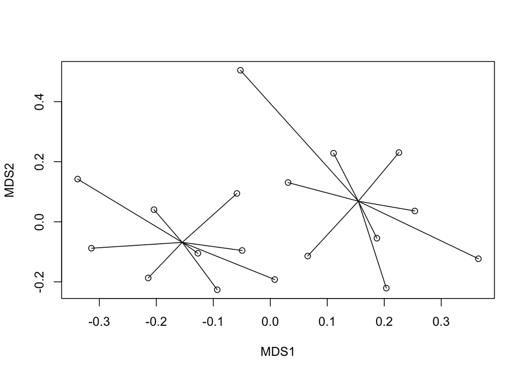

```r
plot(eel.nmds.pts)
ordispider(eel.nmds, gear.eel$gear, display = "sites")
```

What is driving the variability/difference in species composition between gear types for the eelgrass sites? We can use simper to look at this

From help documentation - “method gives the contribution of each species to overall dissimilarities, but these are caused by variation in species abundances, and only partly by diff. among groups.”

```r
sim.eel <- simper(full.eel, gear.eel$gear, permutations = 999)
summary(sim.eel)
```

```
##
## Contrast: beach_seine_eDNA
##
##                             average       sd  ratio    ava    avb cumsum     p
## Clupeidae                  0.047102 0.009441 4.9892 0.0000 1.0000 0.1187 0.001
## Ammodytidae                0.027376 0.023868 1.1470 0.2222 0.6667 0.1877 0.106
## Citharichthys stigmaeus    0.025389 0.024330 1.0435 0.1111 0.5556 0.2517 0.023
## Pleuronectidae             0.024885 0.024764 1.0049 0.4444 0.6667 0.3145 0.240
## Teleostei                  0.023504 0.022110 1.0631 0.1111 0.5556 0.3737 0.077
## Gadidae                    0.023494 0.023414 1.0034 0.5556 0.3333 0.4329 0.596
## Syngnathus leptorhynchus   0.022533 0.026284 0.8573 1.0000 0.5556 0.4897 0.003
## Sebastidae                 0.021895 0.023416 0.9351 0.3333 0.4444 0.5449 0.794
## Gasterosteus               0.021511 0.025013 0.8600 0.6667 0.6667 0.5991 0.961
## Aulorhynchus flavidus      0.020862 0.022863 0.9125 0.4444 0.2222 0.6517 0.573
## Stichaeidae                0.018739 0.025263 0.7418 0.6667 0.8889 0.6989 0.515
## Salmonidae                 0.018347 0.024970 0.7347 0.6667 0.8889 0.7452 0.375
## Hexagrammidae              0.017608 0.024965 0.7053 0.7778 0.7778 0.7896 0.959
## Lepidogobius lepidus       0.016287 0.021738 0.7492 0.1111 0.3333 0.8306 0.169
## Blepsias cirrhosus         0.014677 0.021345 0.6876 0.3333 0.0000 0.8676 0.209
## Citharichthys sordidus     0.014205 0.020582 0.6902 0.3333 0.0000 0.9034 0.207
## Polypera greeni            0.014119 0.020346 0.6939 0.0000 0.3333 0.9390 0.060
## Agonidae                   0.009706 0.018595 0.5220 0.2222 0.0000 0.9635 0.431
## Pholidae                   0.005664 0.016302 0.3474 0.8889 1.0000 0.9777 0.889
## Clupidae                   0.004499 0.012895 0.3489 0.1111 0.0000 0.9891 0.947
## Liparis fucensis           0.004329 0.012411 0.3488 0.0000 0.1111 1.0000 0.138
## Cottidae                   0.000000 0.000000    NaN 1.0000 1.0000 1.0000 1.000
## Embiotocidae               0.000000 0.000000    NaN 1.0000 1.0000 1.0000 1.000
## Rhinogobiops nicholsii     0.000000 0.000000    NaN 0.0000 0.0000 1.0000 1.000
## Ronquilus jordani          0.000000 0.000000    NaN 0.0000 0.0000 1.0000 1.000
## Nautichthys oculofasciatus 0.000000 0.000000    NaN 0.0000 0.0000 1.0000 1.000
## Anoplopoma fimbria         0.000000 0.000000    NaN 0.0000 0.0000 1.0000 1.000
## Brosmophycis marginata     0.000000 0.000000    NaN 0.0000 0.0000 1.0000 1.000
## Gobiesox maeandricus       0.000000 0.000000    NaN 0.0000 0.0000 1.0000 1.000
## Rhamphocottus richardsonii 0.000000 0.000000    NaN 0.0000 0.0000 1.0000 1.000
##
## Clupeidae                  ***
## Ammodytidae
## Citharichthys stigmaeus    *
## Pleuronectidae
## Teleostei                  .
```

[output cut: 14 more lines]

```
## Clupidae
## Liparis fucensis
## Cottidae
## Embiotocidae
## Rhinogobiops nicholsii
## Ronquilus jordani
## Nautichthys oculofasciatus
## Anoplopoma fimbria
## Brosmophycis marginata
## Gobiesox maeandricus
## Rhamphocottus richardsonii
## ---
## Signif. codes:  0 '***' 0.001 '**' 0.01 '*' 0.05 '.' 0.1 ' ' 1
## Permutation: free
## Number of permutations: 999
```

We can also look at species that are significantly correlated with the nmds axes. Because it looks like the variability between gear type falls along the first axis can look at what species drive that seperation of gear type

```r
# create df of scores across some variable (habitat or habitat richness, year, julian etc)
scrs <- as.data.frame(scores(eel.nmds, display = 'sites'))
scrs <- cbind(as.data.frame(scrs), gear = gear.eel$gear)
cent <- aggregate(cbind(NMDS1, NMDS2) ~ gear, data =scrs, FUN = mean)
segs <- merge(scrs, setNames(cent, c('gear', 'oNMDS1', 'oNMDS2')),
              by = "gear", sort = FALSE)

# create species vectors correlated w/ nmds axis - untransformed data
vec.sp <- envfit(eel.nmds$points, full.eel[,1:30], perm = 999)
vec.sp.arrows <- scores(vec.sp, display = "vectors")
vec.sp.dat <- data.frame(vec.sp.arrows)
vec.sp.dat$pvals <- vec.sp$vectors$pvals
vec.sp.dat$sp_code <- row.names(vec.sp.dat)
vec.sp.dat$r2 <- vec.sp$vectors$r

# filter by species that are sig correlated w/ nmds axis
vec.sp.dat.sig <- vec.sp.dat %>%
  filter(pvals < 0.05)

vec.sp.dat.sig <- vec.sp.dat.sig %>%
  dplyr::select(MDS1, MDS2, pvals, sp_code, r2)

# scale by nmds?
scalefactor <- min(max(scrs$NMDS1) - min(scrs$NMDS1), max(scrs$NMDS2) - min(scrs$NMDS2))
vec.sp.dat.sig$MDS1_sc <- vec.sp.dat.sig$MDS1 * (scalefactor * vec.sp.dat.sig$r2)
vec.sp.dat.sig$MDS2_sc <- vec.sp.dat.sig$MDS2 * (scalefactor * vec.sp.dat.sig$r2)
```

Visualize the nmds w/ beach seine eDNA data with species vectors

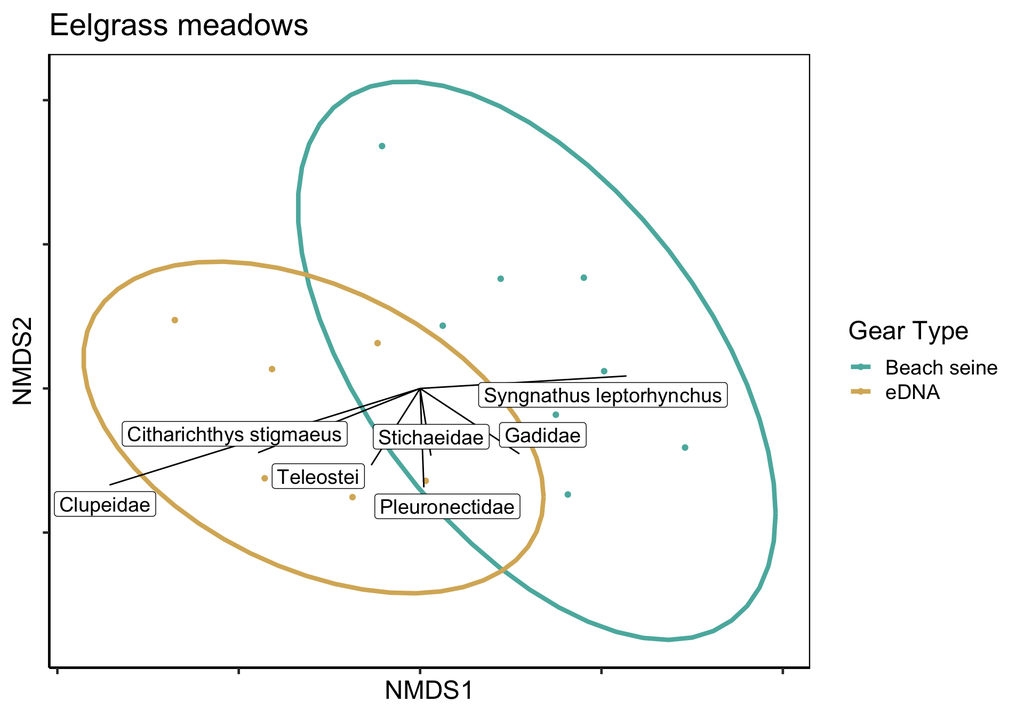

Figure 14: Nonmetric multidimensional scaling of species communities with eelgrass meadows. Color represents the gear type used to sample the community - either beach seine or environmental DNA. Species vectors are species that are significnatly correlated with the NMDS axes and length represents the strength of that correlation (r2)

Based on both the simper and correlation analyses (using envfit) it looks like herring (clupeidae) and bay pipefish (Syngnathus leptorhynchus) are the species that are strongly correlated with the first axis of the nmds. With hering being more strongly correlated with the eDNA samples and bay pipefish more strongly correlated with beach seine methods. Citharicthys sitgmaeus (speckled sanddab) were more associated with eDNA than beach seine.

Why do I think this? Well for instance, groups of herring might be present nearby the site that was sampled but because the beach seines can only sample a limited area perhaps the group of herring were just missed. Similar with the flatfishes (speckled sanddab) especially since they are bottom associated; however, they are found in some seines so that doesn’t explain it fully.

What is particular interesting is that bay pipefish separate the eDNA and beach seine - and are found in seines when they are not found in eDNA. Could this be related to the fact that they are more closely related to sea horses and have closer to plates rather than scales - less slime?

## Kelp PCoA

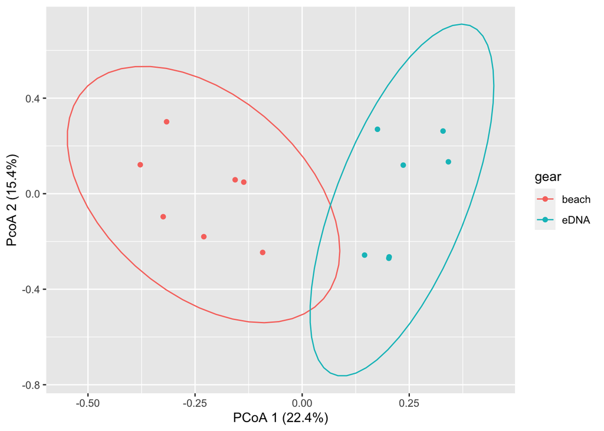

```r
# kelpc.jacc - jaccard distance kelp only sites
kelpc.pco <- cmdscale(kelpc.jacc, k =2, eig = T, add = T)
colnames(kelpc.pco$points) <- c("pcoa1", "pcoa2")


percent_explained5 <- 100* kelpc.pco$eig/ sum(kelpc.pco$eig)
pe5 <- format(round(percent_explained5[1:2], digits = 1), nsmall = 1, trim = T)

pco.perc5 <- c(glue("PCoA 1 ({pe5[1]}%)"),
          glue("PcoA 2 ({pe5[2]}%)"))

kelpc.pco$points %>%
  as_tibble(rownames = "bay_id_gear") %>%
  separate(bay_id_gear, into = c("bay", "id", "gear", "extra"), extra = "merge") %>%
  dplyr::select(-extra) %>%
  unite(bay_id, bay:id) %>%
  left_join(seine.info) %>%
  ggplot(aes(x = pcoa1, y = pcoa2)) +
  geom_point(aes(color = gear)) +
  labs(x = pco.perc5[1], y = pco.perc5[2]) +
  stat_ellipse(aes(color = gear))
```

definitely looks like its seperating between gear type along the first axis